# Week2 - Data Dive Summaries

Raghuveer Venkatesh

2024-09-11

# Introduction

Welcome to our exploration of FIFA Players Data. In this notebook, we’re diving into the world of football players to uncover some interesting insights about their attributes and how they stack up against each other.

# Here’s what we’ll be looking at:

Getting to Know the Data: We’ll start by summarizing the basics—like the ages, heights, and overall ratings of the players. We’ll also check out how players are distributed across different nationalities. Finally, we will visualize how a player’s physical attributes change by age and how their wages are related to their overall rating.

**Foot Preferences and Ratings:** Ever wondered if a player’s preferred foot (left or right) affects their performance? We’ll explore whether there’s a noticeable difference in average ratings between players who favor their left foot versus their right.

**Top Footballing Nations:** We’ll identify which countries have the most players in the dataset. This will give us a snapshot of which nations are most represented in the world of football.

**Player Count vs. Performance:** Finally, we’ll investigate if there’s a pattern between the number of players from a country and their average ratings. Do countries with more players tend to have higher ratings?

**Visualization: Physical attributes vs Age:** Ever wondered how a Player’s physical attributes change by age ?

**Visualization: Player earning vs Overall rating:** How does a Football Player’s earning depend on their overall rating ?

# Summarising the numeric columns - age, height, overall rating for the players

```r
# For numeric columns
numeric_summary <- Fifa_Players_Data |>
  summarise(
    age_min = min(age, na.rm = TRUE),
    age_max = max(age, na.rm = TRUE),
    age_mean = mean(age, na.rm = TRUE),
    age_median = median(age, na.rm = TRUE),
    age_25th = quantile(age, 0.25, na.rm = TRUE),
    age_75th = quantile(age, 0.75, na.rm = TRUE),
    height_min = min(height_cm, na.rm = TRUE),
    height_max = max(height_cm, na.rm = TRUE),
    height_mean = mean(height_cm, na.rm = TRUE),
    height_median = median(height_cm, na.rm = TRUE),
    height_25th = quantile(height_cm, 0.25, na.rm = TRUE),
    height_75th = quantile(height_cm, 0.75, na.rm = TRUE),
    overall_rating_min = min(overall_rating, na.rm = TRUE),
    overall_rating_max = max(overall_rating, na.rm = TRUE),
    overall_rating_mean = mean(overall_rating, na.rm = TRUE),
    overall_rating_median = median(overall_rating, na.rm = TRUE),
    overall_rating_25th = quantile(overall_rating, 0.25, na.rm = TRUE),
    overall_rating_75th = quantile(overall_rating, 0.75, na.rm = TRUE)
  )

#For Category Columns - Nationality
nationality_counts <- Fifa_Players_Data |>
  count(nationality) |>
  rename(Category = nationality, Count = n) |>
  mutate(Column = "nationality")

# Combine the data frames into a single summary table
summary_table <- bind_rows(nationality_counts)

# Arrange the summary table by Column and Category for better readability
summary_table <- summary_table |>
  arrange(Column, desc(Count))
```

## Numeric Summary

```r
print(numeric_summary)
```

```
## # A tibble: 1 × 18
##   age_min age_max age_mean age_median age_25th age_75th height_min height_max
##     <dbl>   <dbl>    <dbl>      <dbl>    <dbl>    <dbl>      <dbl>      <dbl>
## 1      17      46     25.6         25       22       29       152.       206.
## # ℹ 10 more variables: height_mean <dbl>, height_median <dbl>,
## #   height_25th <dbl>, height_75th <dbl>, overall_rating_min <dbl>,
## #   overall_rating_max <dbl>, overall_rating_mean <dbl>,
## #   overall_rating_median <dbl>, overall_rating_25th <dbl>,
## #   overall_rating_75th <dbl>
```

## Printing Categorical Summary

```r
print(summary_table)
```

```
## # A tibble: 160 × 3
##    Category    Count Column
##    <chr>       <int> <chr>
##  1 England      1658 nationality
##  2 Germany      1199 nationality
##  3 Spain        1070 nationality
##  4 France        925 nationality
##  5 Argentina     904 nationality
##  6 Brazil        832 nationality
##  7 Italy         655 nationality
##  8 Colombia      624 nationality
##  9 Japan         466 nationality
## 10 Netherlands   441 nationality
## # ℹ 150 more rows
```

### Observations

The top 10 nationalities in the dataset are dominated by England, with the highest number of players at 1,658, followed by Germany and Spain. Although there’s a significant drop after the top three, countries like the Netherlands still contribute notable numbers of players. Overall, these figures highlight England’s prominent presence in the dataset, while showing diverse representation from other major footballing nations.

## **Some novel questions and answers from the dataset:**

### Question 1: What is the average overall rating of players based on their preferred foot?

```r
  average_rating_by_foot <- Fifa_Players_Data |>
    group_by(preferred_foot) |>
    summarise(average_overall_rating = mean(overall_rating, na.rm = TRUE)) |>
    arrange(desc(average_overall_rating))

  print(average_rating_by_foot)
```

```
## # A tibble: 2 × 2
##   preferred_foot average_overall_rating
##   <chr>                           <dbl>
## 1 Left                             66.8
## 2 Right                            66.1
```

### Observations and Conclusion

This small difference suggests that a player’s preferred foot has a negligible impact on their average overall rating.

### Question 2: Which are the top 10 nations with the highest representation in FIFA?

```r
#Compute top 10 nations
top_10_nations <- nationality_counts |>
  arrange(desc(Count)) |>
  head(10)

print(top_10_nations)
```

```
## # A tibble: 10 × 3
##    Category    Count Column
##    <chr>       <int> <chr>
##  1 England      1658 nationality
##  2 Germany      1199 nationality
##  3 Spain        1070 nationality
##  4 France        925 nationality
##  5 Argentina     904 nationality
##  6 Brazil        832 nationality
##  7 Italy         655 nationality
##  8 Colombia      624 nationality
##  9 Japan         466 nationality
## 10 Netherlands   441 nationality
```

### Observations and Conclusion

1. England has the highest representation with 1,658 players, significantly leading over the other nationalities.
2. The representation decreases gradually from England to the Netherlands, with the Netherlands having the lowest count among the top 10 at 441 players.

### Question 3: Do Nationalities with Higher Player Counts Have Higher Average Ratings?

```r
avg_rating_by_nationality <- Fifa_Players_Data |>
  group_by(nationality) |>
  summarise(
    player_count = n(),
    avg_rating = mean(overall_rating, na.rm = TRUE)
  ) |>
  arrange(desc(player_count))

print(avg_rating_by_nationality)
```

```
## # A tibble: 160 × 3
##    nationality player_count avg_rating
##    <chr>              <int>      <dbl>
##  1 England             1658       63.6
##  2 Germany             1199       66.1
##  3 Spain               1070       69.6
##  4 France               925       67.9
##  5 Argentina            904       68.7
##  6 Brazil               832       71.1
##  7 Italy                655       68.8
##  8 Colombia             624       65.2
##  9 Japan                466       62.6
## 10 Netherlands          441       67.9
## # ℹ 150 more rows
```

### Observations and Conclusion

Brazil stands out with the highest average rating of 71.05. Despite having fewer players compared to some other nations, Brazilian players tend to perform better on average. This suggests Brazil’s footballers are among the best in this data set.

# Let’s understand how a Player’s Physical Attributes change by Age

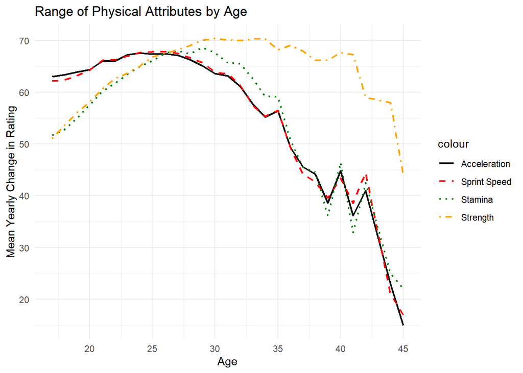

```r
# Assuming your data is in a data frame named "player_data"
player_data_summary <- Fifa_Players_Data |>
  filter(age <= 45) |>
  group_by(age) |>
  summarize(
    mean_acceleration = mean(acceleration),
    mean_sprint_speed = mean(sprint_speed),
    mean_stamina = mean(stamina),
    mean_strength = mean(strength)
  )

ggplot(player_data_summary, aes(x = age)) +
  geom_line(aes(y = mean_acceleration, color = "Acceleration"), linetype = 1, size = 0.8) +
  geom_line(aes(y = mean_sprint_speed, color = "Sprint Speed"), linetype = 2, size = 0.8) +
  geom_line(aes(y = mean_stamina, color = "Stamina"), linetype = 3, size = 0.8) +
  geom_line(aes(y = mean_strength, color = "Strength"), linetype = 4, size = 0.8) +
  labs(
    title = "Range of Physical Attributes by Age",
    x = "Age",
    y = "Mean Yearly Change in Rating"
  ) +
  scale_color_manual(values = c("Acceleration" = "#000000", "Sprint Speed" = "#FF0000", "Stamina" = "#008000", "Strength" = "#FFA500")) +
  theme_minimal()
```

# Observations and Conclusion

As football players get older, their speed and agility naturally decline. While they might gain some muscle mass and strength, they often find it harder to keep up with younger players. This is especially true for skills like acceleration and sprint speed, which are crucial for attacking players.

# Understanding how Player’s wage relates to their Overall Rating

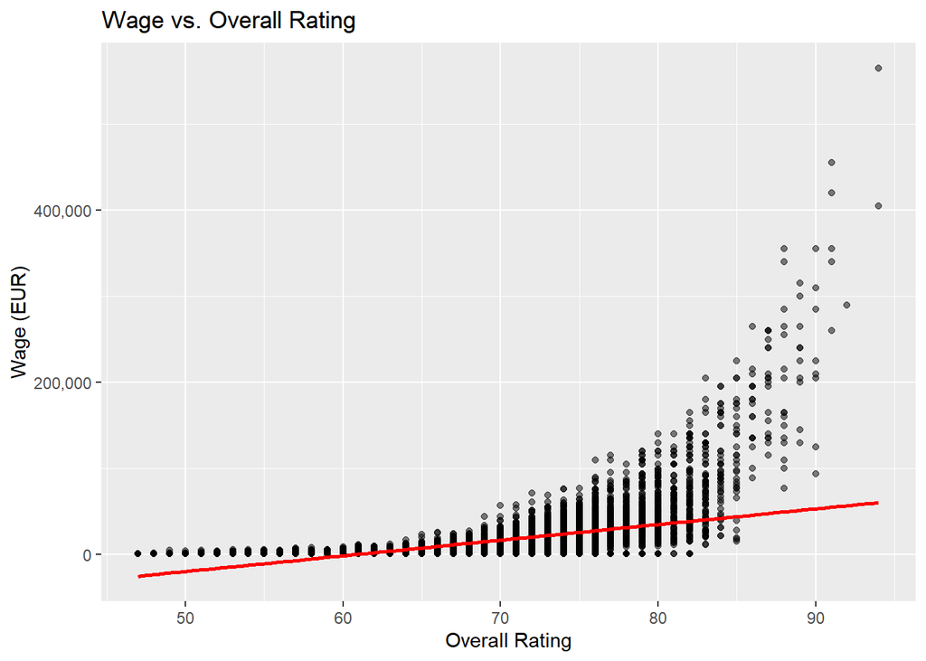

```r
ggplot(Fifa_Players_Data, aes(x = overall_rating, y = wage_euro)) +
  geom_point(data = Fifa_Players_Data %>%
             filter(!is.na(wage_euro) & !is.infinite(wage_euro)),
             alpha = 0.5) +
  geom_smooth(formula = 'y ~ x',
             data = Fifa_Players_Data %>%
             filter(!is.na(wage_euro) & !is.infinite(wage_euro)),
             method = "lm", se = FALSE, color = "red") +
  labs(title = "Wage vs. Overall Rating",
       x = "Overall Rating",
       y = "Wage (EUR)") +
  scale_y_continuous(labels = scales::comma)
```

# Observations and Conclusion

Overall rating is a strong predictor of wage, but other factors like age, potential, and nationality also influence player performance and earnings.